# Bulk Density in Organic Soils

Wills et al

October 18, 2017

comparing datasets

## Bulk Density data

### Bring in datasets with SOC and bulk density across a range of conditions.

**NCSS** - National Cooperative Soil Survey Characterization dataset. National Cooperative Soil Survey (also known as the soil survey characterization database). Available by query or Access database at: https://ncsslabdatamart.sc.egov.usda.gov/. Preparation of this dataset covered as part of the RaCA project, following Wills et al., 2013. Prepped from the public dataset (Access) from August 2015 following the methods in the RaCA documentation - Prep SOC and BD data.doc.

**RaCA** - Rapid Carbon Assessment Project. Information and data available at https://www.nrcs.usda.gov/wps/portal/nrcs/detail/soils/survey/?cid=nrcs142p2_054164

**NWCA** - National Wetland Condition Assessment. Information and data available at: https://www.nrcs.usda.gov/wps/portal/nrcs/detail/soils/survey/?cid=nrcs142p2_054164 Data for this project was made available as part of the soil property cooperation with Kellogg Soil Survey Laboratory.

**ISCN** -International Soil Carbon Network. Data available at http://iscn.fluxdata.org/data/data-summary/ Data for this project was supplied by ISCN for BD modeling and population.

**this code chunk downloads data into the folder you set to BD_data - uncomment to run**

```r
# set folder name to desired download location
BD_data <- "D:/Disk 2/BD_eval/"  #shortcut for personal use

# #download file to the working directory - creates new
# folder data #will save raw data into this folder
# ifelse(!dir.exists(paste0(BD_data,'/data')),
# dir.create(paste0(BD_data,'/data')), FALSE) #True means the
# file was created, FALSE means it alread exsists ncss.url <-
# 'https://nrcs.box.com/shared/static/kroh8h124zligmamsorsk18d98gt9qkd.csv'
# #if file does not exsist, download
# ifelse(!file.exists('data/ncss.w.bd.csv'),download.file(ncss.url,
# destfile = paste0(BD_data,'/data/ncss.w.bd.csv')), 'File
# already downloaded') raca.url <-
# 'https://nrcs.box.com/shared/static/nivz52qvsgyalx5zir8sgcu7lpp048pl.csv'
# ifelse(!file.exists('data/RaCA_samples.csv'),
# download.file(raca.url, destfile =
# paste0(BD_data,'/data/RaCA_samples.csv') ) , 'File already
# downloaded') nwca.url <-
# 'https://nrcs.box.com/shared/static/u3qahrgycjzenwxykiabh93cnmk4r1e6.csv'
# ifelse(!file.exists('data/nwca.SOCsamples_5-10.csv'),
# download.file(nwca.url, destfile =
# paste0(BD_data,'/data/nwca.SOCsamples_5-10.csv')), 'File
# already downloaded')

# ISDCN multiple files must be joined Local copy used to
# derive BD model - includes additional fields such as master
# horizon iscn.url <-
# 'https://nrcs.box.com/shared/static/4abhdlvwxt8196fs99r25s46spvsmcok.csv'
# ifelse(!file.exists('data/ISCN_BDfill_pred_wMEtA.csv'),download.file(iscn.url,
# destfile =
# paste0(BD_data,'/data/ISCN_BDfill_pred_wMEtA.csv')), 'File
# already downloaded')

# # iscnNLCD.url <-
# 'http://iscn.fluxdata.org/wp-content/uploads/sites/15/ISCN_Template_NLCD.xlsx'
# ifelse(!file.exists('data/ISCN_Template_NLCD.xlsx'),download.file(iscnNLCD.url,
# destfile = paste0(BD_data,'data/ISCN_Template_NLCD.xlsx')),
# 'File already downloaded')

# iscnPROFILE.url <-
# 'ftp://ftp.fluxdata.org/.deba/ISCN/ALL-DATA/ISCN_ALL-DATA_PROFILE_1-1.xlsx'
# ifelse(!file.exists('data/ISCN_ALL-DATA_PROFILE_1-1.xlsx'),download.file(iscnPROFILE.url,
# destfile =
# paste0(BD_data,'data/ISCN_ALL-DATA_PROFILE_1-1.xlsx')),
# 'File already downloaded')
```

## Read Data into R and Prep

#### Combine dataset into one

- Check field names
- Select relevant fields
- Harmonize datasets
- Rename to same field names
- Add SET to denote dataset
- Add any missing fields (assign values or unknown)
  - LU - to match RaCA W- wetland, C- cropland, P- pastureland, F - Forestland, X- CRP, U added for unknown

*Texture labels need to be assessed in ensure the same abbreviations are being used* *wpg for ISCN needs to be converted to volumetric fragment content*

```r
# load datasets, create common columns, filter and label as
# needed
ncss <- read.csv(paste0(BD_data, "data/ncss.w.bd.csv"))
names(ncss)
```

```
#  [1] "sample_id"     "upedonid"      "mod_pedon_key" "pedlabsampnum"
#  [5] "Order"         "top"           "bottom"        "Model_desg"
#  [9] "M"             "Hzn_avg"       "Thick"         "Texture"
# [13] "SAND"          "SILT"          "CLAY"          "SOC"
# [17] "BD"            "samp"          "above"         "below"
# [21] "ped"           "Actual"        "labsampnum"    "hzn_desgn"
# [25] "c_tot"         "oc"            "carb"          "CF"
# [29] "tex_descrp"    "tex_psda"      "Bulk.Density"  "BD.source"
```

```r
ncss$SOC <- ifelse(ncss$SOC < 0, 0, ncss$SOC)
n <- ncss[!is.na(ncss$BD), c("sample_id", "top", "bottom", "Model_desg",
    "M", "tex_psda", "CLAY", "SOC", "CF", "BD")]
names(n) <- c("samp_id", "Top", "Bottom", "Model_desg", "M",
    "Texture", "Clay", "SOC", "CourseFrag", "BD")
n$LU <- "U"  #U for unknown landuse
n$SET <- "NCSS"

raca <- read.csv(paste0(BD_data, "data/RaCA_samples.csv"))
names(raca)
```

```
#  [1] "samp"                "sample.id"           "TOP"
#  [4] "BOT"                 "hzn_desgn"           "rcasiteid"
#  [7] "pedon_no"            "MO"                  "MOGr"
# [10] "hor_top"             "hor_bot"             "fragvolc"
# [13] "Bulkdensity"         "SOC_pred1"           "BD1"
# [16] "upedonid"            "upedon"              "LU"
# [19] "MOGrLU"              "hzname"              "model_desg1"
# [22] "texture"             "BDmeasured"          "BDmethod"
# [25] "Lab.Sample.No"       "lab_proj_name"       "submit_proj_name"
# [28] "user_site_id"        "smp_id"              "lay_field_label1"
# [31] "lay_field_label2"    "lay_field_label3"    "lay_depth_to_top"
# [34] "lay_depth_to_bottom" "horizon_designation" "natural_key"
# [37] "lay_id"              "adod"                "c_tot_ncs"
# [40] "n_tot_ncs"           "s_tot_ncs"           "caco3"
# [43] "efferv_1nhcl"        "M"                   "Model_desg"
# [46] "Texture"             "Measure_BD"          "Model_BD"
```

```r
raca$CALC_SOC <- ifelse(!is.na(raca$caco3), ifelse(raca$caco3 >
    0, raca$c_tot_ncs - (raca$caco3 * 0.12), raca$c_tot_ncs),
    raca$c_tot_ncs)
raca$SOC <- ifelse(raca$CALC_SOC < 0, 0, raca$CALC_SOC)
r <- raca[!is.na(raca$Measure_BD), c("samp", "TOP", "BOT", "Model_desg",
    "M", "texture", "fragvolc", "SOC", "Measure_BD", "LU")]
names(r) <- c("samp_id", "Top", "Bottom", "Model_desg", "M",
    "Texture", "CourseFrag", "SOC", "BD", "LU")
r$SET <- "RaCA"
r$Clay <- NA

nwca <- read.csv(paste0(BD_data, "/data/nwca.SOCsamples_5-10.csv"))
names(nwca)
```

```
#  [1] "samp"           "Pedon"          "Order"          "top"
#  [5] "bottom"         "Model_desg"     "M"              "Hzn_avg"
#  [9] "Thick"          "Texture"        "SAND"           "SILT"
# [13] "CLAY"           "SOC"            "BD"             "Model"
# [17] "Measured"       "SITE_PIT_VISIT" "UID"            "DATE_COL"
# [21] "SITE_ID"        "SITE_USE"       "VISIT_NO"       "PIT"
# [25] "REP_PIT"        "LAYER"          "HORIZON"        "TOP"
# [29] "BOTTOM"         "SANDY"          "LOAMY"          "MK_MIN"
# [33] "ORGANIC"        "ROCK_FRAGMENTS" "TEXTURE_CLASS"  "Bulk.Density"
# [37] "SOCd"           "SOC_5"          "SOC_30"         "SOC_100"
# [41] "SOCden"         "SOCstock5"      "SOCstock30"     "SOCstock100"
```

```r
w <- nwca[!is.na(nwca$BD), c("samp", "top", "bottom", "Model_desg",
    "M", "TEXTURE_CLASS", "CLAY", "ROCK_FRAGMENTS", "SOC", "BD")]
names(w) <- c("samp_id", "Top", "Bottom", "Model_desg", "M",
    "Texture", "Clay", "CourseFrag", "SOC", "BD")
w$LU <- "W"
w$SET <- "NWCA"

iscn <- read.csv(paste0(BD_data, "data/ISCN_BDfill_pred_wMEtA.csv"))
names(iscn)
```

```
#  [1] "hzn_desgn"        "dataset_name"     "site_name"
#  [4] "profile_name"     "layer_name"       "layer_top"
#  [7] "layer_bot"        "c_method"         "bd_method"
# [10] "BD"               "bd_tot"           "bd_whole"
# [13] "bd_other"         "bdNRCS_prep_code" "SAND"
# [16] "SILT"             "CLAY"             "wpg2_method"
# [19] "wpg2"             "soc"              "soc_sigma"
# [22] "soc_method"       "SOC"              "oc"
# [25] "cNRCS_prep_code"  "typ"              "ID"
# [28] "model_desg"       "md2"              "M"
# [31] "m"                "Model_desg"       "Thick"
# [34] "Hzn_avg"          "hzn_desgn.1"      "dataset_name.1"
# [37] "site_name.1"      "profile_name.1"   "BDfill.ALT.pred"
# [40] "BDfill.lab.pred"  "X"                "resid_lab"
```

```r
iscn$vpg <- iscn$wpg2 * iscn$BD  #convert weight coarse frags to volume
i <- iscn[!is.na(iscn$BD), c("layer_name", "layer_top", "layer_bot",
    "model_desg", "M", "CLAY", "vpg", "SOC", "BD")]
names(i) <- c("samp_id", "Top", "Bottom", "Model_desg", "M",
    "Clay", "CourseFrag", "SOC", "BD")
i$Clay <- as.numeric(i$Clay)
i$Texture <- "U"
i$LU <- "U"
i$SET <- "ISCN"

iscnNLCD <- read.csv(paste0(BD_data, "data/ISCN_Template_NLCD.xlsx"))

iscnPROFILE <- read.csv(paste0(BD_data, "data/ISCN_ALL-DATA_PROFILE_1-1.xlsx"))




# combine dataset into one - missing values are filled with
# NA
combo <- rbind(n, r, w, i)

# there are a number of really high bulk density numbers -
# primarily in the ISCN set - need to investigate further
combo <- combo %>% filter(BD < 2)
```

## Compare Datasets

Use dplyr (with piping) to format and ggplot to create graphs

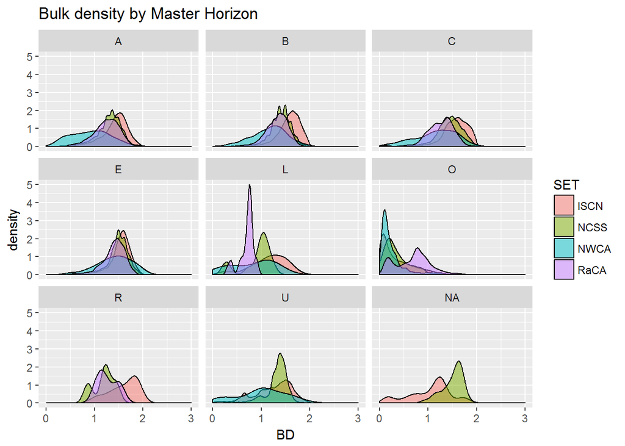

```r
d <- combo %>% ggplot(aes(BD)) + geom_density(aes(fill = SET),
    alpha = 0.5) + scale_x_continuous(limits = c(0, 3)) + facet_wrap(~M) +
    ggtitle("Bulk density by Master Horizon")
d
```

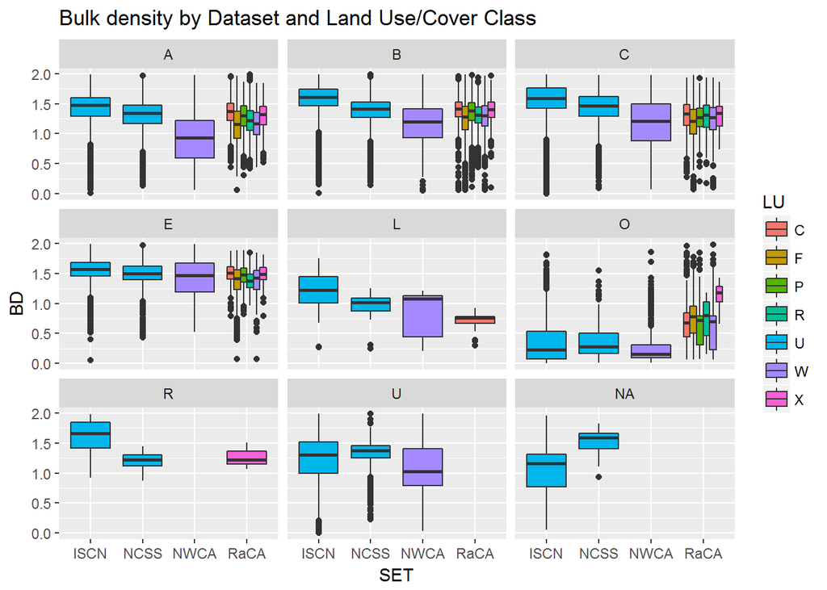

```r
b <- combo %>% # filter(!is.na(BD)) %>%
ggplot(aes(y = BD, x = SET)) + geom_boxplot(aes(fill = LU)) +
    facet_wrap(~M) + ggtitle("Bulk density by Dataset and Land Use/Cover Class")
b
```

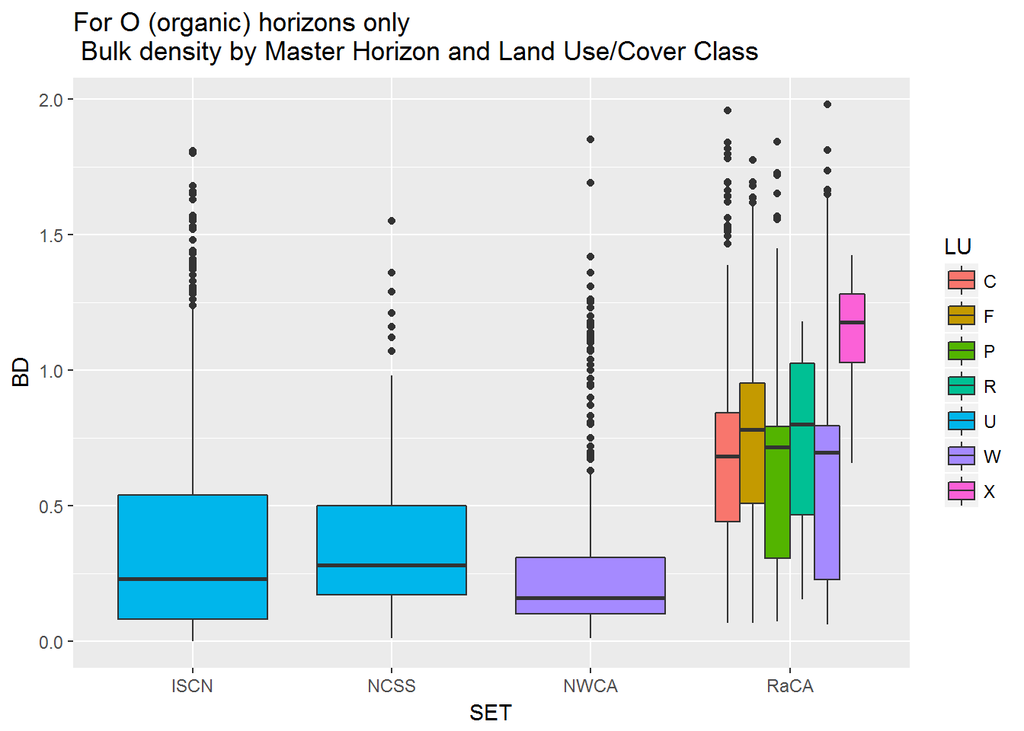

```r
o <- combo %>% filter(!is.na(BD) & M == "O") %>% ggplot(aes(y = BD,
    x = SET)) + geom_boxplot(aes(fill = LU)) + ggtitle("For O (organic) horizons only \n Bulk density by Master Horizon and Land Use/Cover Class")
o
```

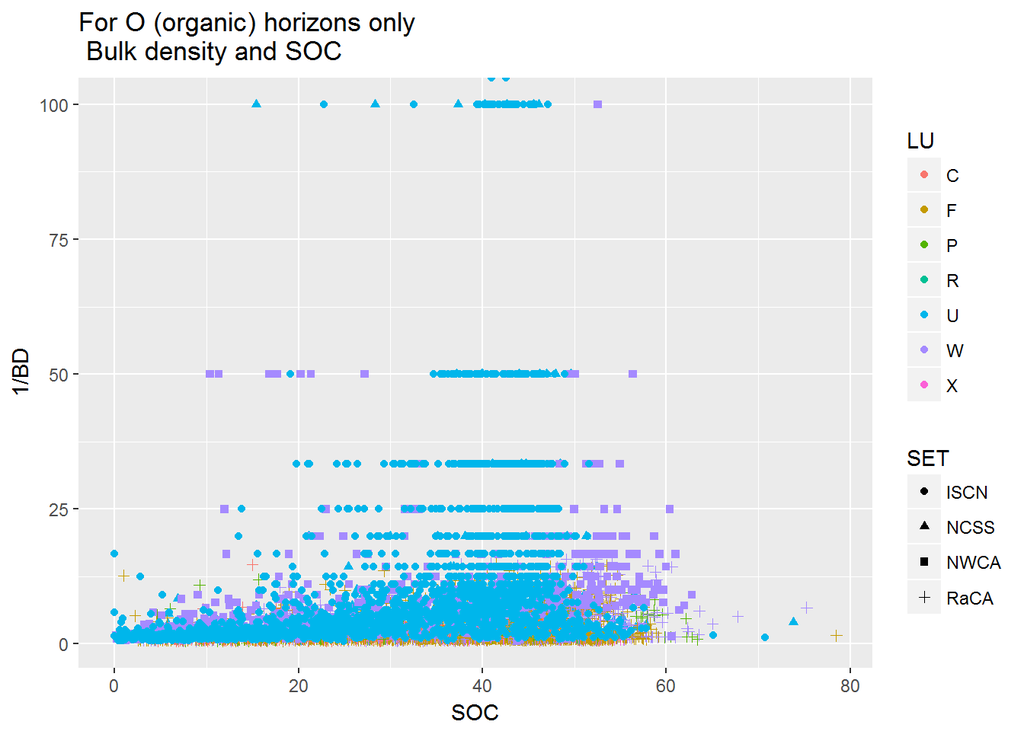

```r
S <- combo %>% filter(!is.na(BD) & M == "O") %>% ggplot(aes(y = 1/BD,
    x = SOC)) + geom_point(aes(color = LU, shape = SET)) + ggtitle("For O (organic) horizons only \n Bulk density and SOC")
S
```

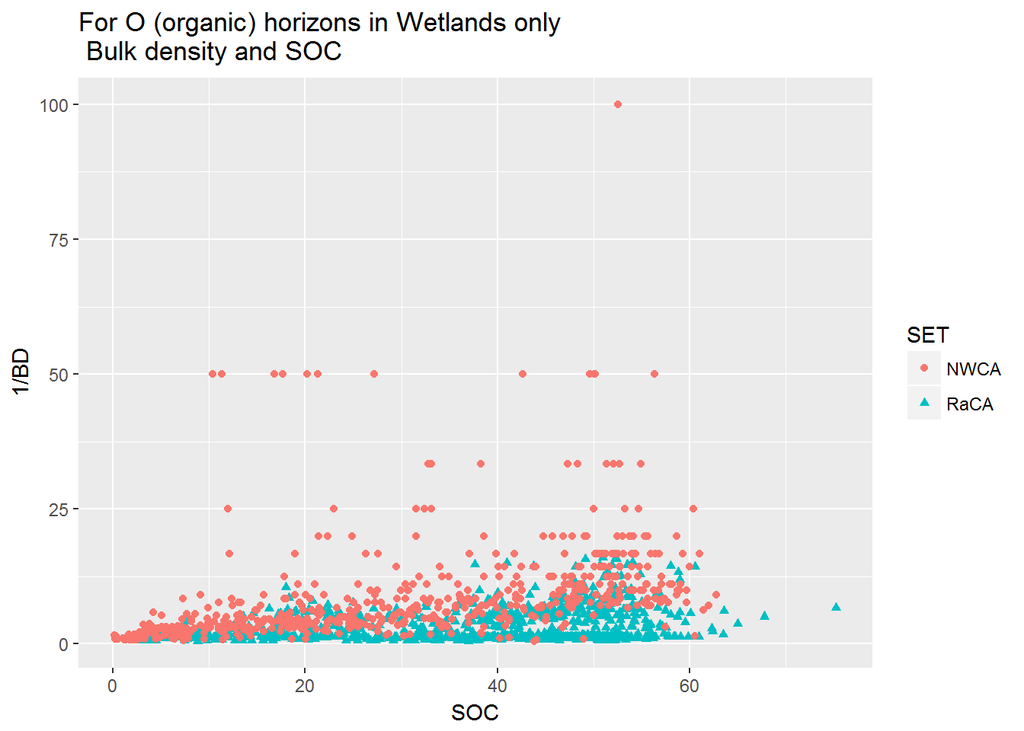

```r
Sw <- combo %>% filter(!is.na(BD) & M == "O" & LU == "W") %>%
    ggplot(aes(y = 1/BD, x = SOC)) + geom_point(aes(color = SET,
    shape = SET)) + ggtitle("For O (organic) horizons in Wetlands only \n Bulk density and SOC")
Sw
```

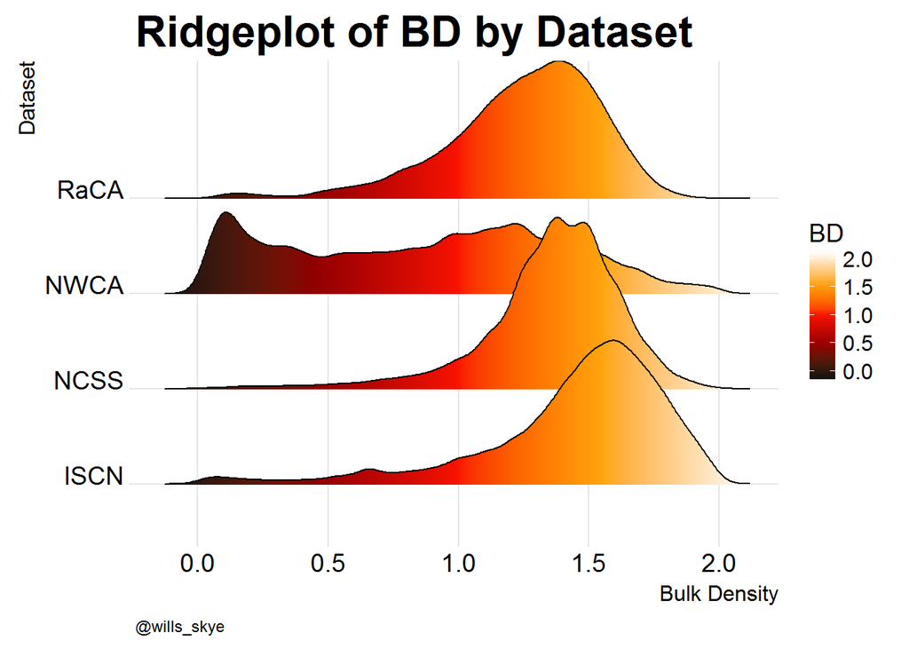

```r
# joy plot with continuous fill
R <- combo %>% filter(!is.na(BD)) %>% ggplot(aes(x = BD, y = SET,
    fill = ..x..)) + geom_joy_gradient() + scale_fill_gradientn(colours = cet_pal(5,
    name = "fire"), name = "BD") + theme_joy() + theme(plot.caption = element_text(hjust = 0,
    size = 9), axis.title = element_text(size = 12), plot.title = element_text(size = 24)) +
    labs(x = "Bulk Density", y = "Dataset", caption = "@wills_skye",
        title = "Ridgeplot of BD by Dataset")

R
```

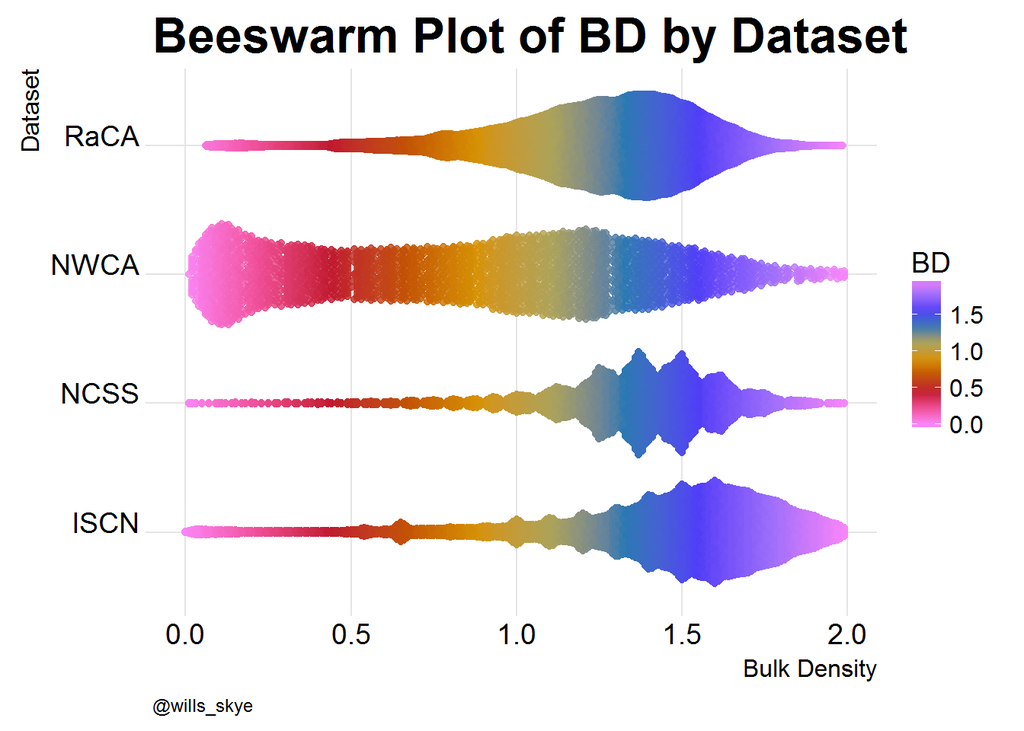

```r
# bee swarm
B <- combo %>% filter(!is.na(BD)) %>% ggplot(aes(x = BD, y = SET,
    color = BD)) + geom_quasirandom(alpha = 0.82, groupOnX = FALSE) +
    scale_color_gradientn(colours = cet_pal(10, name = "cyclic_mrybm_35-75_c68_n256"),
        name = "BD") + theme_joy() + theme(plot.caption = element_text(hjust = 0,
    size = 9), axis.title = element_text(size = 12), plot.title = element_text(size = 24)) +
    labs(x = "Bulk Density", y = "Dataset", caption = "@wills_skye",
        title = "Beeswarm Plot of BD by Dataset")

B
```

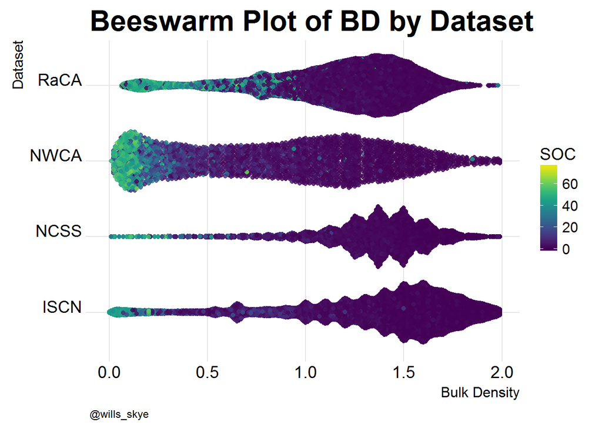

```r
# add SOC measurement for visulaization
B_C <- combo %>% filter(!is.na(BD) & !is.na(SOC)) %>% ggplot(aes(x = BD,
    y = SET, color = SOC)) + geom_quasirandom(alpha = 0.82, groupOnX = FALSE) +
    scale_color_viridis() + theme_joy() + theme(plot.caption = element_text(hjust = 0,
    size = 9), axis.title = element_text(size = 12), plot.title = element_text(size = 24)) +
    labs(x = "Bulk Density", y = "Dataset", caption = "@wills_skye",
        title = "Beeswarm Plot of BD by Dataset")

B_C
```

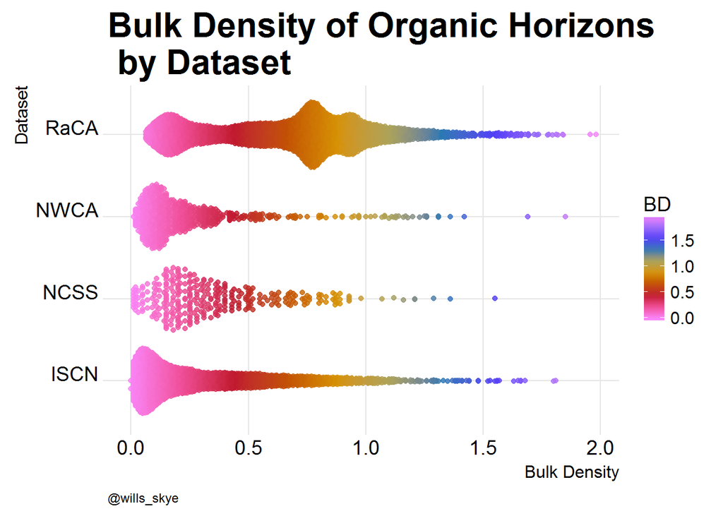

```r
# limit to organic horizons bee swarm
Bo <- combo %>% filter(!is.na(BD) & M == "O") %>% ggplot(aes(x = BD,
    y = SET, color = BD)) + geom_quasirandom(alpha = 0.82, groupOnX = FALSE) +
    scale_color_gradientn(colours = cet_pal(10, name = "cyclic_mrybm_35-75_c68_n256"),
        name = "BD") + theme_joy() + theme(plot.caption = element_text(hjust = 0,
    size = 9), axis.title = element_text(size = 12), plot.title = element_text(size = 24)) +
    labs(x = "Bulk Density", y = "Dataset", caption = "@wills_skye",
        title = "Bulk Density of Organic Horizons \n by Dataset")

Bo
```

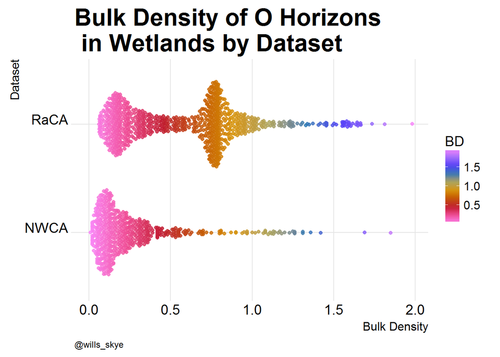

```r
Bow <- combo %>% filter(!is.na(BD) & M == "O" & LU == "W") %>%
    ggplot(aes(x = BD, y = SET, color = BD)) + geom_quasirandom(alpha = 0.82,
    groupOnX = FALSE) + scale_color_gradientn(colours = cet_pal(10,
    name = "cyclic_mrybm_35-75_c68_n256"), name = "BD") + theme_joy() +
    theme(plot.caption = element_text(hjust = 0, size = 9), axis.title = element_text(size = 12),
        plot.title = element_text(size = 24)) + labs(x = "Bulk Density",
    y = "Dataset", caption = "@wills_skye", title = "Bulk Density of O Horizons \n in Wetlands by Dataset")

Bow
```

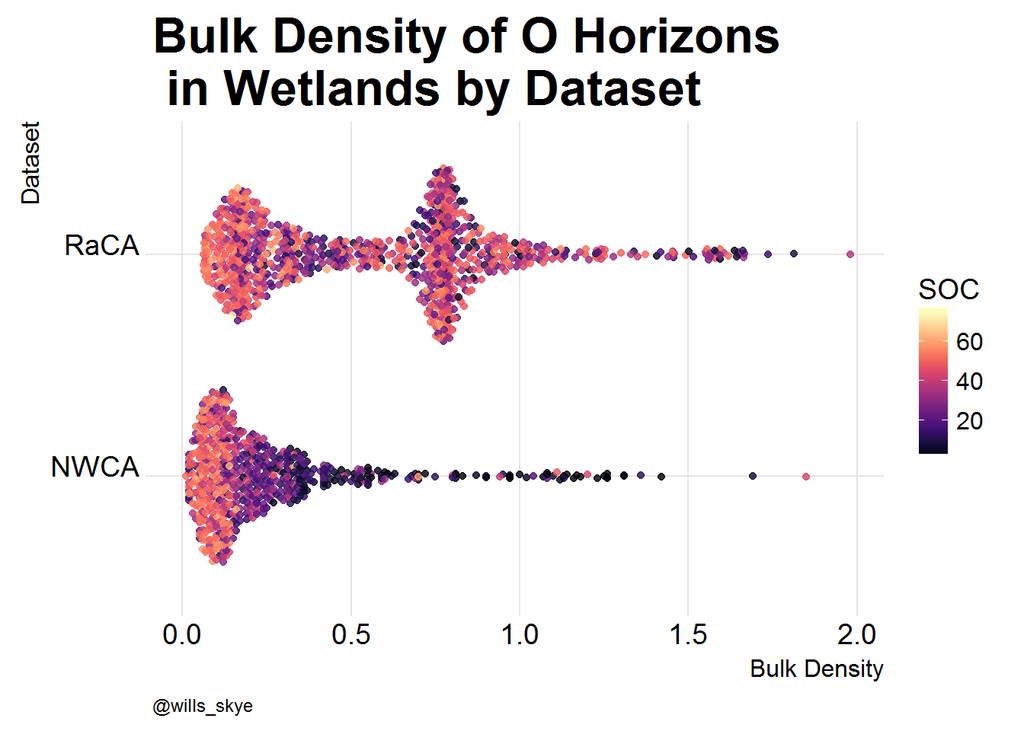

```r
# with SOC measurement
BowC <- combo %>% filter(!is.na(BD) & !is.na(SOC) & M == "O" &
    LU == "W") %>% ggplot(aes(x = BD, y = SET, color = SOC)) +
    geom_quasirandom(alpha = 0.82, groupOnX = FALSE) + scale_color_viridis(option = "magma") +
    theme_joy() + theme(plot.caption = element_text(hjust = 0,
    size = 9), axis.title = element_text(size = 12), plot.title = element_text(size = 24)) +
    labs(x = "Bulk Density", y = "Dataset", caption = "@wills_skye",
        title = "Bulk Density of O Horizons \n in Wetlands by Dataset")

BowC
```

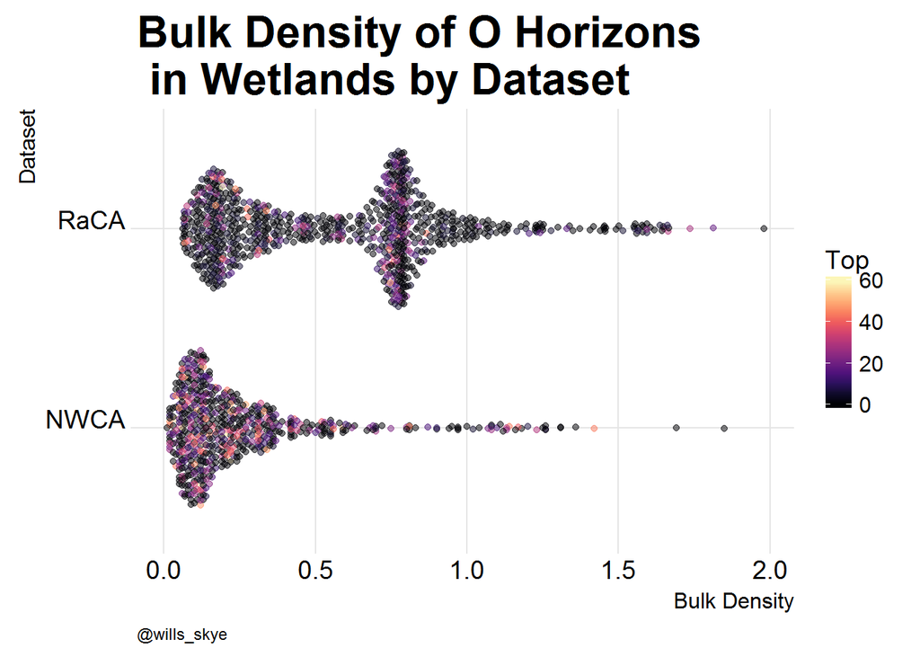

```r
BowT <- combo %>% filter(!is.na(BD) & !is.na(SOC) & M == "O" &
    LU == "W") %>% ggplot(aes(x = BD, y = SET, color = Top)) +
    geom_quasirandom(alpha = 0.5, groupOnX = FALSE) + scale_color_viridis(option = "magma") +
    theme_joy() + theme(plot.caption = element_text(hjust = 0,
    size = 9), axis.title = element_text(size = 12), plot.title = element_text(size = 24)) +
    labs(x = "Bulk Density", y = "Dataset", caption = "@wills_skye",
        title = "Bulk Density of O Horizons \n in Wetlands by Dataset")

BowT
```

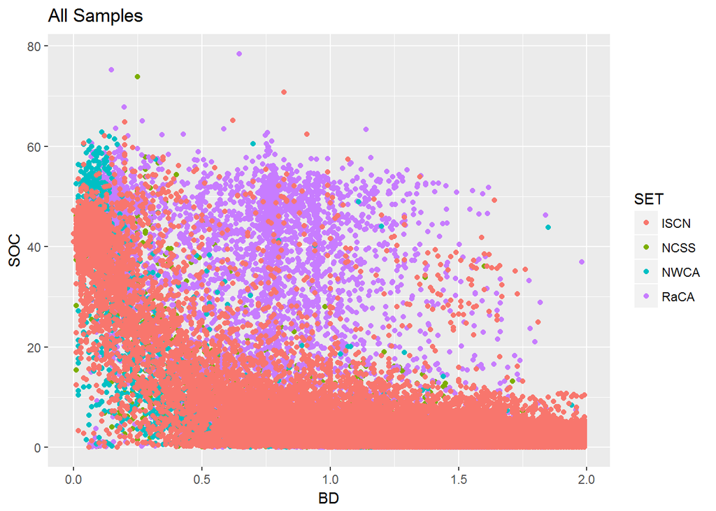

```r
ap <- combo %>% filter(!is.na(BD) & !is.na(SOC)) %>% ggplot(aes(x = BD,
    y = SOC, color = SET)) + geom_point() + ggtitle("All Samples")

ap
```

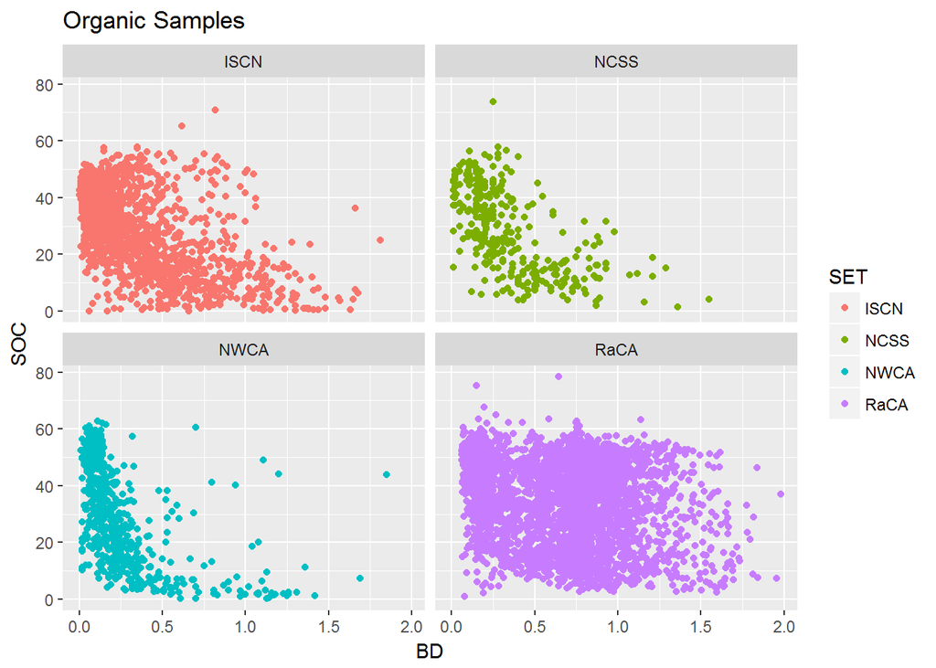

```r
op <- combo %>% filter(!is.na(BD) & !is.na(SOC) & M == "O") %>%
    ggplot(aes(x = BD, y = SOC, color = SET)) + geom_point() +
    ggtitle("Organic Samples")

opf <- op + facet_wrap(~SET)
opf
```

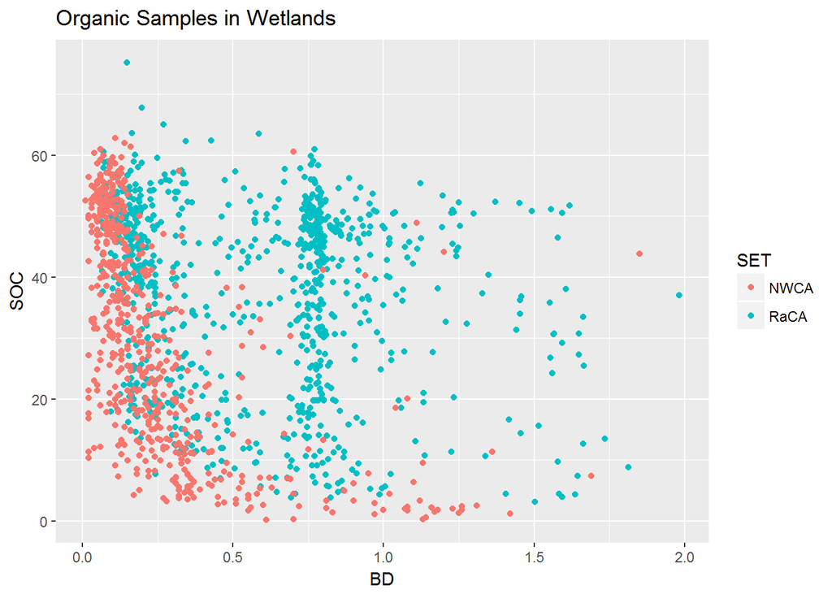

```r
wp <- combo %>% filter(!is.na(BD) & !is.na(SOC) & M == "O" &
    LU == "W") %>% ggplot(aes(x = BD, y = SOC, color = SET)) +
    geom_point() + ggtitle("Organic Samples in Wetlands")

wp
```

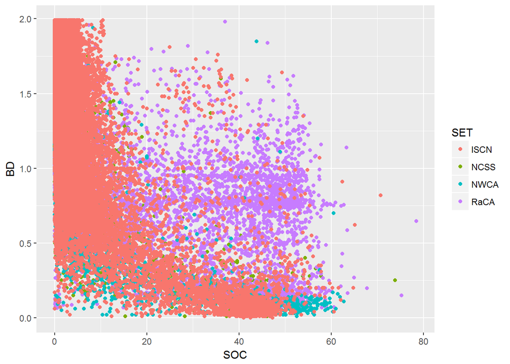

```r
YP <- combo %>% filter(!is.na(BD) & !is.na(SOC)) %>% ggplot(aes(x = SOC,
    y = BD, color = SET)) + geom_point()
YP
```

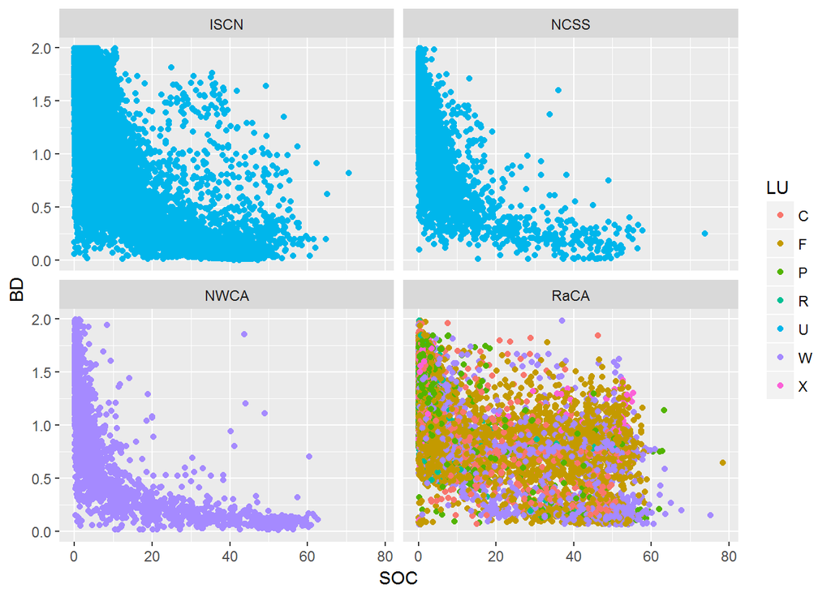

```r
YPf <- combo %>% filter(!is.na(BD) & !is.na(SOC)) %>% ggplot(aes(x = SOC,
    y = BD)) + geom_point(aes(color = LU)) + facet_wrap(~SET)
YPf
```

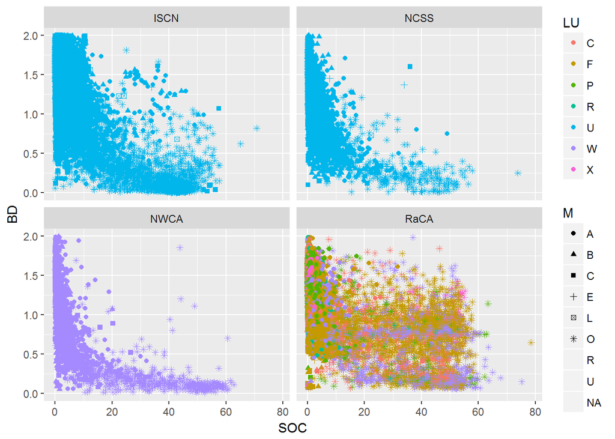

```r
YPm <- combo %>% filter(!is.na(BD) & !is.na(SOC)) %>% ggplot(aes(x = SOC,
    y = BD)) + geom_point(aes(shape = M, color = LU)) + facet_wrap(~SET)
YPm
```

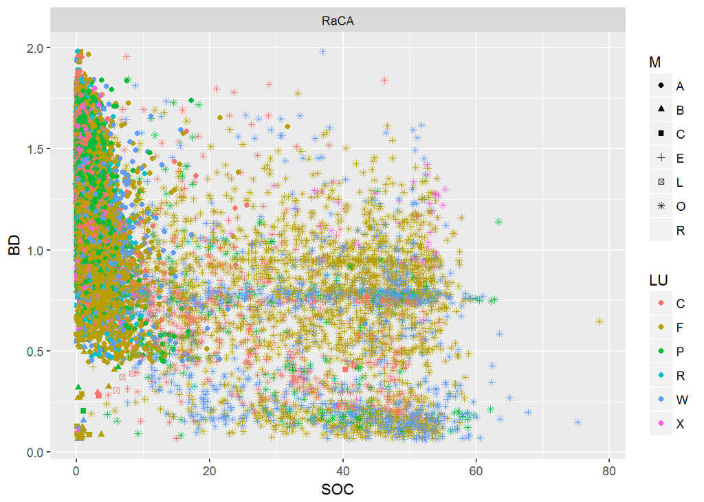

```r
hp <- combo %>% filter(!is.na(BD) & !is.na(SOC) & SET == "RaCA")

YhPm <- hp %>% ggplot(aes(x = SOC, y = BD)) + geom_point(aes(shape = M,
    color = LU)) + facet_wrap(~SET)
YhPm
```

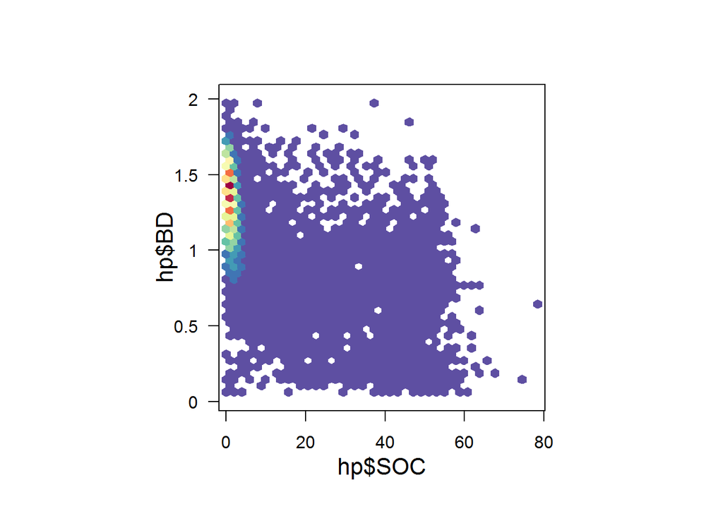

```r
hex <- ggplot(data = hp, aes(x = SOC, y = BD)) + ggtitle("RaCA Samples") +
    geom_hex(bins = 75) + scale_fill_gradient2(low = "blue",
    mid = "white", high = "green", midpoint = 150)

ho <- combo %>% filter(!is.na(BD) & !is.na(SOC) & SET == "RaCA" &
    M == "O") %>% ggplot(aes(x = SOC, y = BD)) + ggtitle("RaCA Organic Samples") +
    geom_hex(bins = 25) + scale_fill_gradient2(low = "blue",
    mid = "white", high = "green", midpoint = 25)


how <- combo %>% filter(!is.na(BD) & !is.na(SOC) & SET == "RaCA" &
    M == "O" & LU == "W" & SOC > 20) %>% ggplot(aes(x = SOC,
    y = BD)) + ggtitle("RaCA Organic - Wetland Samples") + geom_hex(bins = 25) +
    scale_fill_gradient2(low = "blue", mid = "white", high = "green",
        midpoint = 10)



# alternate hex
library(hexbin)
library(RColorBrewer)

# Make the plot
bin <- hexbin(hp$SOC, hp$BD, xbins = 40)
my_colors = colorRampPalette(rev(brewer.pal(11, "Spectral")))
plot(bin, main = "", colramp = my_colors, legend = F)
```

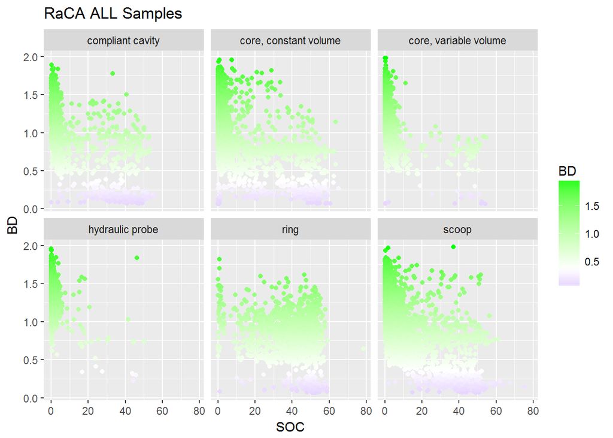

```r
am <- raca %>% filter(!is.na(Measure_BD) & !is.na(SOC)) %>% mutate(BD = Measure_BD) %>%
    ggplot(aes(x = SOC, y = BD)) + ggtitle("RaCA ALL Samples") +
    geom_point(aes(color = BD)) + scale_color_gradient2(low = "blue",
    mid = "white", high = "green", midpoint = 0.35) + facet_wrap(~BDmethod)

am
```

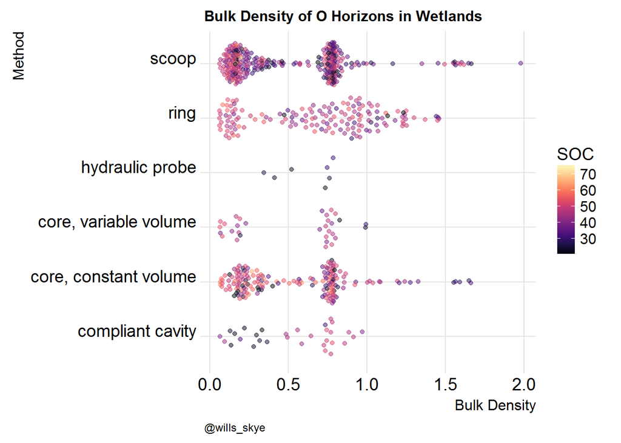

```r
# there is a significant number of RaCA samples in the
# intermediate level of bulk density and some much higher
# even when SOC is greater than 20%



r_O <- raca %>% filter(!is.na(Measure_BD) & !is.na(SOC) & M ==
    "O" & LU == "W" & SOC > 20) %>% select("rcasiteid", "pedon_no",
    "MO", "MOGr", "TOP", "BOT", "hzn_desgn", "Model_desg", "M",
    "texture", "fragvolc", "caco3", "SOC", "BDmethod", "Measure_BD",
    "LU") %>% mutate(BD = Measure_BD, BD_class = cut(BD, breaks = c(0,
    0.5, 1, 2.5), labels = c("low", "med", "high")), fit = 0.0906 +
    0.8757 * exp(-0.0786 * SOC) + 0.65528 * exp(-1.0975 * SOC),
    dev = BD - fit)


write_csv(r_O, "C:/Users/Skye.Wills/ownCloud/AGU_BD-OM/raca-r_O.csv")


mp <- r_O %>% ggplot(aes(x = SOC, y = BD)) + ggtitle("RaCA Organic Wetland Samples") +
    geom_point(aes(color = BD)) + scale_fill_gradient2(low = "blue",
    mid = "white", high = "green", midpoint = 150) + facet_wrap(~BDmethod)

mb <- r_O %>% ggplot(aes(x = BDmethod, y = dev)) + ggtitle("RaCA Organic Wetland Samples") +
    geom_boxplot(aes(color = BDmethod))

mbs <- r_O %>% ggplot(aes(x = BD, y = BDmethod, color = SOC)) +
    geom_quasirandom(alpha = 0.5, groupOnX = FALSE) + scale_color_viridis(option = "magma") +
    theme_joy() + theme(plot.caption = element_text(hjust = 0,
    size = 9), axis.title = element_text(size = 12), plot.title = element_text(size = 12)) +
    labs(x = "Bulk Density", y = "Method", caption = "@wills_skye",
        title = "Bulk Density of O Horizons in Wetlands")

mbs
```

```r
library(dplyr)  #reloading to use this syntax over plyr

r_sum <- r_O %>% group_by(BD_class) %>% summarize(count = length(BD_class),
    bd = mean(BD), soc = mean(SOC), t = mean(TOP), b = mean(BOT))


# Try to identify some key thing that could indicate BD
# values outside of 'usual'

r_O %>% group_by(BD_class, BDmethod) %>% summarize(n = length(BD_class)) %>%
    spread(key = BD_class, value = n)
```

| BDmethod | low | med | high |
| --- | --- | --- | --- |
| compliant cavity | 14 | 17 | NA |
| core, constant volume | 83 | 78 | 15 |
| core, variable volume | 13 | 18 | NA |
| hydraulic probe | 2 | 5 | NA |
| ring | 47 | 69 | 34 |
| scoop | 161 | 133 | 17 |

```r
r_O %>% group_by(BD_class, MO) %>% summarize(n = length(BD_class)) %>%
    spread(key = BD_class, value = n)
```

| MO | low | med | high |
| --- | --- | --- | --- |
| 4 | 40 | NA | NA |
| 5 | 7 | NA | NA |
| 7 | 22 | 21 | NA |
| 10 | 47 | 49 | 17 |
| 11 | 15 | 14 | 1 |
| 12 | 16 | 19 | 5 |
| 13 | 6 | 40 | 15 |
| 14 | 146 | 132 | 27 |
| 15 | 15 | 41 | 1 |
| 16 | 6 | 4 | NA |

```r
r_O %>% group_by(BD_class, hzn_desgn) %>% summarize(n = length(BD_class)) %>%
    spread(key = BD_class, value = n)
```

| hzn_desgn | low | med | high |
| --- | --- | --- | --- |
| oa | 45 | 56 | 23 |
| oa1 | 81 | 54 | NA |
| oa2 | 28 | 46 | 4 |
| oa3 | 2 | 11 | 1 |
| oa4 | NA | 1 | NA |
| oe | 79 | 60 | 24 |
| oe1 | 11 | 7 | NA |
| oe2 | 7 | 4 | NA |
| oei | 1 | 4 | NA |
| oi | 57 | 62 | 14 |
| oi1 | 9 | 2 | NA |
| oi2 | NA | 10 | NA |
| oie | NA | 3 | NA |

```r
r_O %>% group_by(BD_class, texture) %>% summarize(n = length(BD_class)) %>%
    spread(key = BD_class, value = n)
```

| texture | low | med | high |
| --- | --- | --- | --- |
|  | 319 | 319 | 64 |
| fs | NA | NA | 1 |
| l | NA | 1 | 1 |
| si | 1 | NA | NA |

```r
# MO10 has a good mix of low, med, and high BD values
r_O %>% filter(MO == "10") %>% select(SOC, BD_class, hzn_desgn) %>%
    group_by(BD_class, hzn_desgn) %>% summarise(soc = mean(SOC)) %>%
    spread(key = BD_class, value = soc)
```

| hzn_desgn | low | med | high |
| --- | --- | --- | --- |
| oa | 47.20741 | 39.45482 | 38.07992 |
| oa1 | 36.85064 | 43.29353 | NA |
| oa2 | NA | 40.03935 | 32.71554 |
| oe | 47.88426 | 49.42357 | NA |
| oi | 49.26195 | 43.38665 | NA |
| oi1 | 50.62350 | 50.57001 | NA |
| oi2 | NA | 49.75398 | NA |

```r
# MO14 has more highs than other MOs
r_O %>% filter(MO == "14") %>% select(SOC, BD_class, hzn_desgn) %>%
    group_by(BD_class, hzn_desgn) %>% summarise(soc = mean(SOC)) %>%
    spread(key = BD_class, value = soc)
```

| hzn_desgn | low | med | high |
| --- | --- | --- | --- |
| oa | 51.42741 | 39.83267 | 35.61673 |
| oa1 | 51.83158 | 54.22972 | NA |
| oa2 | 50.97443 | 42.10292 | NA |
| oa3 | NA | 45.51602 | 50.60182 |
| oe | 49.15811 | 46.26168 | 38.16719 |
| oe1 | 26.34693 | NA | NA |
| oe2 | 21.02390 | 48.45029 | NA |
| oei | 44.83940 | 51.99823 | NA |
| oi | 49.07652 | 44.89881 | 42.97136 |
| oi1 | 32.62092 | NA | NA |
| oi2 | NA | 32.59918 | NA |
| oie | NA | 46.37417 | NA |

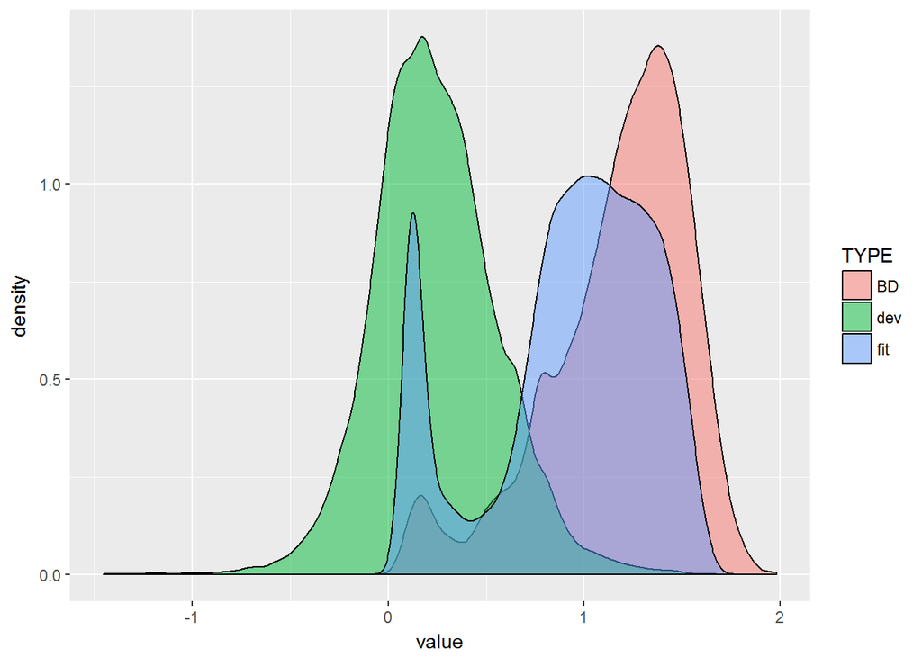

```r
## trying to look at the correlation between sample, pedon and
## plot problems

raca <- raca %>% filter(!is.na(Measure_BD) & !is.na(SOC)) %>%
    select("samp", "rcasiteid", "pedon_no", "MO", "MOGr", "TOP",
        "BOT", "hzn_desgn", "Model_desg", "M", "texture", "fragvolc",
        "caco3", "SOC", "BDmethod", "Measure_BD", "LU") %>% mutate(ped = paste0(rcasiteid,
    "_", pedon_no), BD = Measure_BD, BD_class = ifelse(M == "O",
    cut(BD, breaks = c(0, 0.5, 1, 2.5), labels = c("low", "med",
        "high")), "Mineral"), fit = 0.0906 + 0.8757 * exp(-0.0786 *
    SOC) + 0.65528 * exp(-1.0975 * SOC), dev = BD - fit)

raca %>% select(samp, BDmethod, BD, fit, dev) %>% gather(key = TYPE,
    value = value, -c(samp, BDmethod)) %>% ggplot(aes(value)) +
    geom_density(aes(fill = TYPE), alpha = 0.5)
```

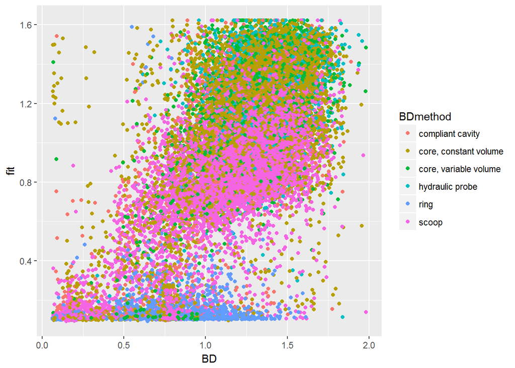

```r
raca %>% select(samp, BDmethod, BD, fit, dev) %>% ggplot(aes(x = BD,
    y = fit, color = BDmethod)) + geom_point(aes(color = BDmethod))
```

```r
# library(dplyr) ped <- raca %>% select(rcasiteid, pedon_no,
# ped, MO, MOGr, SOC, BD, dev) %>% group_by(ped) %>%
# summarise_all(funs(min, mean, max)) %>%
# rename_(.dots=setNames(names(.), tolower(gsub('_', '_ped_',
# names(.))))) site <- raca %>% select(rcasiteid, pedon_no,
# ped, MO, MOGr, SOC, BD, dev) %>% group_by(rcasiteid) %>%
# summarise_all(funs(min, mean, max))%>%
# rename_(.dots=setNames(names(.), tolower(gsub('_',
# '_site_', names(.))))) raca_dev <- raca %>% left_join(ped)
# %>% left_join(site) raca_dev %>% ggplot(aes(bd_ped_mean,
# bd_site_mean)) + geom_point(aes(color = BD_class)) +
# ggtitle('Mean Deviation from Modeled BD') raca_dev %>%
# ggplot(aes(dev, bd_site_mean)) + geom_point(aes(color =
# BD_class)) + ggtitle('Sample vs. Mean Deviation from
# Modeled BD') grid.arrange( raca_dev %>% ggplot(aes(x = BD,
# color = BD_class)) + geom_density(aes(fill = BD_class),
# alpha= 0.5)+ ggtitle('BD Classes by distribution') ,
# raca_dev %>% ggplot(aes(x = fit, color = BD_class)) +
# geom_density(aes(fill = BD_class), alpha= 0.5)+
# ggtitle('Deviation from Model by BD class') , raca_dev %>%
# ggplot(aes(BD, fit)) + geom_point(aes(color = BD_class)) +
# ylim(0,2) + xlim(0,2) + ggtitle('all') , raca_dev %>%
# filter(M == 'O') %>% ggplot(aes(dev, BD)) +
# geom_point(aes(color = BD_class)) + ylim(0,2) + xlim(-1,2)
# +ggtitle('Organic') , ncol = 2, top = 'RaCA Horizons Bulk
# Density') grid.arrange( raca_dev %>% filter(M == 'O') %>%
# ggplot(aes(x = BD, color = BD_class)) +
# geom_density(aes(fill = BD_class), alpha= 0.5)+ ggtitle('BD
# Classes by distribution') , raca_dev %>% filter(M == 'O')
# %>% ggplot(aes(x = dev, color = BD_class)) +
# geom_density(aes(fill = BD_class), alpha= 0.5)+
# ggtitle('Deviation from Model by BD class') , raca_dev %>%
# filter(M == 'O') %>% ggplot(aes(dev, dev_ped_mean)) +
# geom_point(aes(color = BD_class)) + ylim(-1,2) + xlim(-1,2)
# + ggtitle('Sample vs. Mean Pedon') , raca_dev %>% filter(M
# == 'O') %>% ggplot(aes(dev, dev_site_mean)) +
# geom_point(aes(color = BD_class)) + ylim(-1,2) + xlim(-1,2)
# +ggtitle('Sample vs. Mean Site') , ncol = 2, top = 'RaCA
# Organic Horizons \n dev = BD Measured - BD Model')
# raca_dev %>% ggplot(aes(x = BD, y = SOC)) +
# geom_point(aes(color = BD_class)) raca_dev %>% ggplot(aes(x
# = BD, y = fit)) + geom_point(aes(color = BD_class)) +
# ylim(0,2) + xlim(0,2) raca_dev %>% ggplot(aes(x = BD_class,
# y = bd_site_mean)) + geom_boxplot(aes(fill = BD_class))
# raca_dev %>%filter(M == 'O')%>% ggplot(aes(x = BD_class, y
# = bd_site_mean)) + geom_boxplot(aes(fill = BD_class))
```

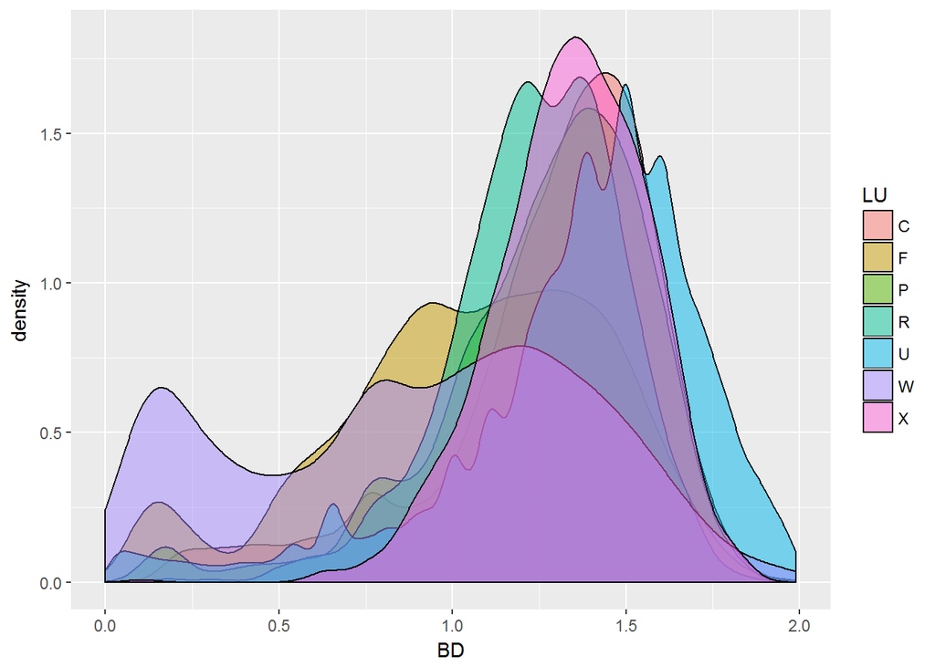

```r
# find lines to predict bulk density from sanderman BD =
# 0.0906 + 0.8757*exp(-0.0786*OC) + 0.65528*exp(-1.0975*OC)

# Only data with BD and SOC
m <- combo %>% filter(!is.na(BD) & !is.na(SOC))


m %>% ggplot(aes(BD)) + geom_density(aes(fill = LU), alpha = 0.5)
```

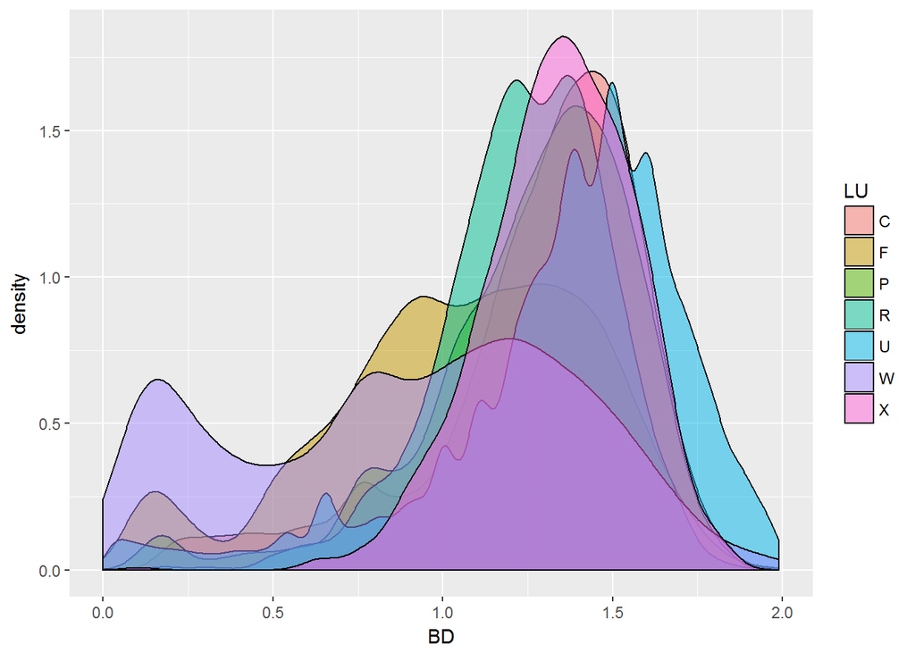

```r
# removing outlier O horizons
m %>% ggplot(aes(BD)) + geom_density(aes(fill = LU), alpha = 0.5)
```

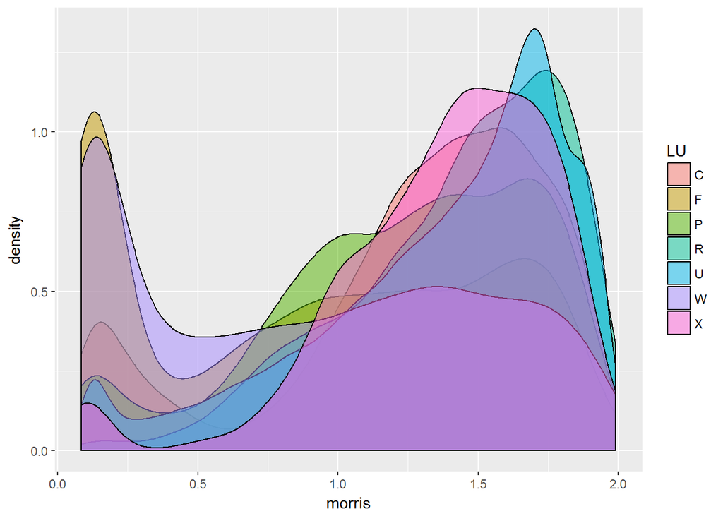

```r
# BASIC graph
yr <- m %>% ggplot(aes(x = SOC, y = BD)) + geom_point() + facet_wrap(~SET)

# linear plot with OM
ys <- m %>% ggplot(aes(x = SOC * 1.724, y = 1/BD)) + geom_point() +
    facet_wrap(~SET)




# #test out various fits (SOC and BD) yr +
# stat_smooth(method='lm', formula = y ~ x + I(x^2), size =
# 1) yr + stat_smooth(method = 'gam', formula = y ~ s(x),
# size = 1) yr + stat_smooth(method = 'lm', formula = y ~
# exp(-(x+0.01))) yr + stat_smooth(method = 'lm', formula = y
# ~ log(x+0.01)) yr + stat_smooth(method = 'lm', se = TRUE,
# formula = y~poly(x, 3, raw = TRUE))

# yr + stat_smooth(method = 'lm', formula = 1/y ~
# log(x+0.01)) yr + stat_smooth(method = 'lm', formula = y ~
# exp(-(x+0.01))) yr + stat_smooth(method = 'lm', formula = y
# ~ 0.0906 + 0.8757*exp(-0.0786*x) + 0.65528*exp(-1.0975*x))
# formalize w equation

# sanderman equation
m$fit <- with(m, 0.0906 + 0.8757 * exp(-0.0786 * SOC) + 0.65528 *
    exp(-1.0975 * SOC))


# mixing model - estimated from Morris et al., 2016 best fit
# a = 8.5 and b = 199

# esimate OM from SOC
m$OM <- m$SOC * 1.724
m$OM <- ifelse(m$OM > 100, 100, m$OM)


a = 8.5
b = 199

m$morris <- with(m, 1/(OM/a + (100 - OM)/b))

# a and b values altered to better fit range of soils in
# these datasets
a = 12
b = 175


m %>% ggplot(aes(morris)) + geom_density(aes(fill = LU), alpha = 0.5)
```

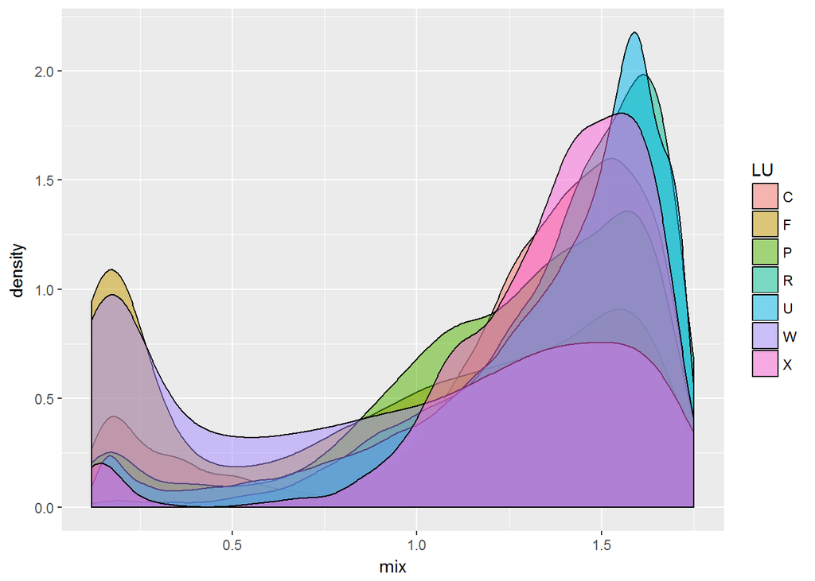

```r
m$mix <- with(m, 1/((OM/a) + ((100 - OM)/b)))


m %>% ggplot(aes(mix)) + geom_density(aes(fill = LU), alpha = 0.5)
```

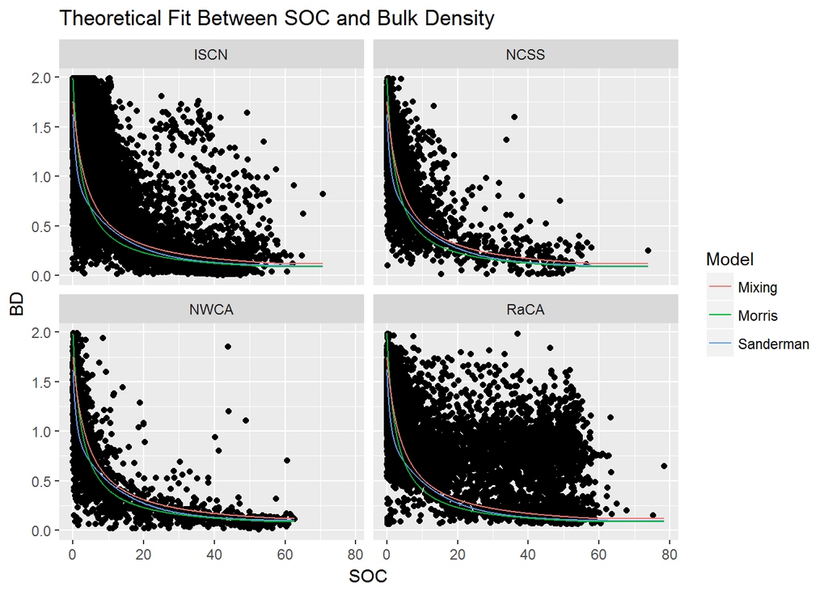

```r
yr + ggtitle("Theoretical Fit Between SOC and Bulk Density") +
    guides(color = guide_legend("Model")) + geom_line(data = m,
    aes(y = fit, colour = "Sanderman")) + geom_line(data = m,
    aes(y = morris, colour = "Morris")) + geom_line(data = m,
    aes(y = mix, colour = "Mixing"))
```

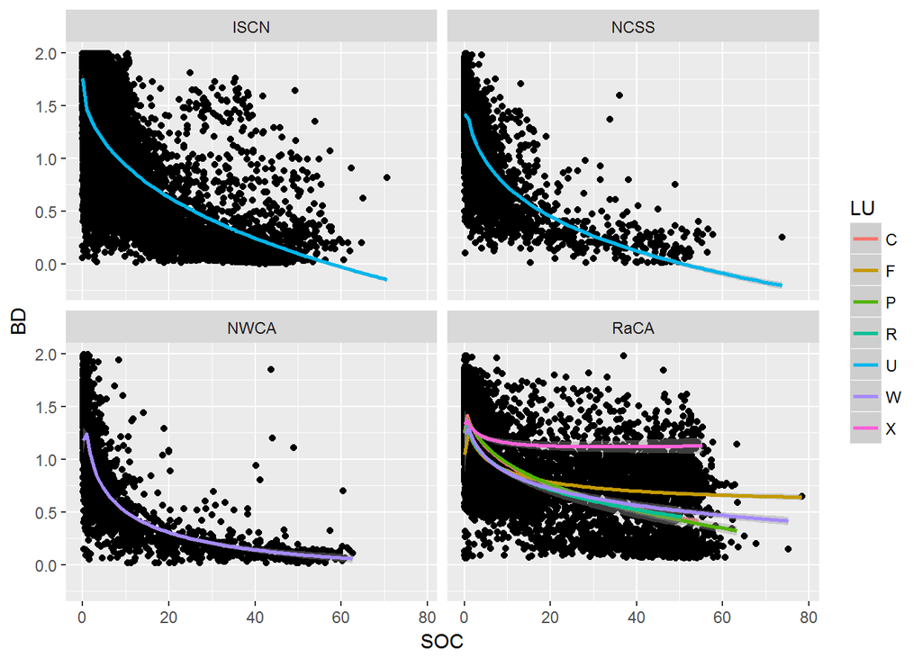

```r
yr + stat_smooth(aes(color = LU), method = "lm", se = TRUE, formula = y ~
    poly(log(x + 0.01), 3, raw = TRUE))
```

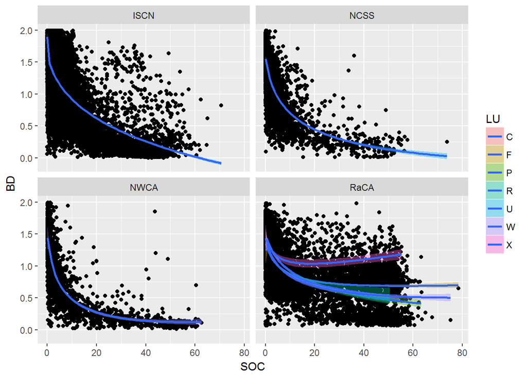

```r
yr + stat_smooth(aes(fill = LU), method = "lm", se = TRUE, formula = y ~
    poly(log(x + 0.01), 4, raw = TRUE))
```